# Risk Factor Analysis

## Outcome Variable

**Outcome Variable:** ever_swasted

## Predictor Variables

**Intervention Variable:** single

**Adjustment Set:**

- arm
- W_mage
- meducyrs
- feducyrs
- W_mhtcm
- W_mwtkg
- W_mbmi
- delta_W_mage
- delta_meducyrs
- delta_feducyrs
- delta_W_mhtcm
- delta_W_mwtkg
- delta_W_mbmi

## Stratifying Variables

The analysis was stratified on these variable(s):

- agecat
- studyid
- country

## Data Summary

| agecat | studyid | country | single | ever_swasted | n_cell | n |
| --- | --- | --- | --- | --- | --- | --- |
| 0-24 months | ki0047075b-MAL-ED | BANGLADESH | 0 | 0 | 242 | 263 |
| 0-24 months | ki0047075b-MAL-ED | BANGLADESH | 0 | 1 | 21 | 263 |
| 0-24 months | ki0047075b-MAL-ED | BANGLADESH | 1 | 0 | 0 | 263 |
| 0-24 months | ki0047075b-MAL-ED | BANGLADESH | 1 | 1 | 0 | 263 |
| 0-24 months | ki0047075b-MAL-ED | BRAZIL | 0 | 0 | 194 | 233 |
| 0-24 months | ki0047075b-MAL-ED | BRAZIL | 0 | 1 | 3 | 233 |
| 0-24 months | ki0047075b-MAL-ED | BRAZIL | 1 | 0 | 35 | 233 |
| 0-24 months | ki0047075b-MAL-ED | BRAZIL | 1 | 1 | 1 | 233 |
| 0-24 months | ki0047075b-MAL-ED | INDIA | 0 | 0 | 223 | 249 |
| 0-24 months | ki0047075b-MAL-ED | INDIA | 0 | 1 | 26 | 249 |
| 0-24 months | ki0047075b-MAL-ED | INDIA | 1 | 0 | 0 | 249 |
| 0-24 months | ki0047075b-MAL-ED | INDIA | 1 | 1 | 0 | 249 |
| 0-24 months | ki0047075b-MAL-ED | NEPAL | 0 | 0 | 231 | 240 |
| 0-24 months | ki0047075b-MAL-ED | NEPAL | 0 | 1 | 9 | 240 |
| 0-24 months | ki0047075b-MAL-ED | NEPAL | 1 | 0 | 0 | 240 |
| 0-24 months | ki0047075b-MAL-ED | NEPAL | 1 | 1 | 0 | 240 |
| 0-24 months | ki0047075b-MAL-ED | PERU | 0 | 0 | 264 | 302 |
| 0-24 months | ki0047075b-MAL-ED | PERU | 0 | 1 | 4 | 302 |
| 0-24 months | ki0047075b-MAL-ED | PERU | 1 | 0 | 34 | 302 |
| 0-24 months | ki0047075b-MAL-ED | PERU | 1 | 1 | 0 | 302 |
| 0-24 months | ki0047075b-MAL-ED | SOUTH AFRICA | 0 | 0 | 169 | 312 |
| 0-24 months | ki0047075b-MAL-ED | SOUTH AFRICA | 0 | 1 | 7 | 312 |
| 0-24 months | ki0047075b-MAL-ED | SOUTH AFRICA | 1 | 0 | 127 | 312 |
| 0-24 months | ki0047075b-MAL-ED | SOUTH AFRICA | 1 | 1 | 9 | 312 |
| 0-24 months | ki0047075b-MAL-ED | TANZANIA, UNITED REPUBLIC OF | 0 | 0 | 244 | 261 |
| 0-24 months | ki0047075b-MAL-ED | TANZANIA, UNITED REPUBLIC OF | 0 | 1 | 7 | 261 |
| 0-24 months | ki0047075b-MAL-ED | TANZANIA, UNITED REPUBLIC OF | 1 | 0 | 8 | 261 |
| 0-24 months | ki0047075b-MAL-ED | TANZANIA, UNITED REPUBLIC OF | 1 | 1 | 2 | 261 |
| 0-24 months | ki1066203-TanzaniaChild2 | TANZANIA, UNITED REPUBLIC OF | 0 | 0 | 2008 | 2375 |
| 0-24 months | ki1066203-TanzaniaChild2 | TANZANIA, UNITED REPUBLIC OF | 0 | 1 | 143 | 2375 |

[output cut: 150 more lines]

The following strata were considered:

- agecat: 0-24 months, studyid: ki0047075b-MAL-ED, country: BANGLADESH
- agecat: 0-24 months, studyid: ki0047075b-MAL-ED, country: BRAZIL
- agecat: 0-24 months, studyid: ki0047075b-MAL-ED, country: INDIA
- agecat: 0-24 months, studyid: ki0047075b-MAL-ED, country: NEPAL
- agecat: 0-24 months, studyid: ki0047075b-MAL-ED, country: PERU
- agecat: 0-24 months, studyid: ki0047075b-MAL-ED, country: SOUTH AFRICA
- agecat: 0-24 months, studyid: ki0047075b-MAL-ED, country: TANZANIA, UNITED REPUBLIC OF
- agecat: 0-24 months, studyid: ki1066203-TanzaniaChild2, country: TANZANIA, UNITED REPUBLIC OF
- agecat: 0-24 months, studyid: ki1112895-Guatemala BSC, country: GUATEMALA
- agecat: 0-24 months, studyid: ki1119695-PROBIT, country: BELARUS
- agecat: 0-24 months, studyid: ki1126311-ZVITAMBO, country: ZIMBABWE
- agecat: 0-24 months, studyid: ki1135781-COHORTS, country: GUATEMALA
- agecat: 0-24 months, studyid: ki1135781-COHORTS, country: INDIA
- agecat: 0-24 months, studyid: ki1135781-COHORTS, country: PHILIPPINES
- agecat: 0-24 months, studyid: kiGH5241-JiVitA-4, country: BANGLADESH
- agecat: 0-6 months, studyid: ki0047075b-MAL-ED, country: BANGLADESH
- agecat: 0-6 months, studyid: ki0047075b-MAL-ED, country: BRAZIL
- agecat: 0-6 months, studyid: ki0047075b-MAL-ED, country: INDIA
- agecat: 0-6 months, studyid: ki0047075b-MAL-ED, country: NEPAL
- agecat: 0-6 months, studyid: ki0047075b-MAL-ED, country: PERU
- agecat: 0-6 months, studyid: ki0047075b-MAL-ED, country: SOUTH AFRICA
- agecat: 0-6 months, studyid: ki0047075b-MAL-ED, country: TANZANIA, UNITED REPUBLIC OF
- agecat: 0-6 months, studyid: ki1066203-TanzaniaChild2, country: TANZANIA, UNITED REPUBLIC OF
- agecat: 0-6 months, studyid: ki1112895-Guatemala BSC, country: GUATEMALA
- agecat: 0-6 months, studyid: ki1119695-PROBIT, country: BELARUS
- agecat: 0-6 months, studyid: ki1126311-ZVITAMBO, country: ZIMBABWE
- agecat: 0-6 months, studyid: ki1135781-COHORTS, country: GUATEMALA
- agecat: 0-6 months, studyid: ki1135781-COHORTS, country: INDIA
- agecat: 0-6 months, studyid: ki1135781-COHORTS, country: PHILIPPINES
- agecat: 0-6 months, studyid: kiGH5241-JiVitA-4, country: BANGLADESH
- agecat: 6-24 months, studyid: ki0047075b-MAL-ED, country: BANGLADESH
- agecat: 6-24 months, studyid: ki0047075b-MAL-ED, country: BRAZIL
- agecat: 6-24 months, studyid: ki0047075b-MAL-ED, country: INDIA
- agecat: 6-24 months, studyid: ki0047075b-MAL-ED, country: NEPAL
- agecat: 6-24 months, studyid: ki0047075b-MAL-ED, country: PERU
- agecat: 6-24 months, studyid: ki0047075b-MAL-ED, country: SOUTH AFRICA
- agecat: 6-24 months, studyid: ki0047075b-MAL-ED, country: TANZANIA, UNITED REPUBLIC OF
- agecat: 6-24 months, studyid: ki1066203-TanzaniaChild2, country: TANZANIA, UNITED REPUBLIC OF
- agecat: 6-24 months, studyid: ki1112895-Guatemala BSC, country: GUATEMALA
- agecat: 6-24 months, studyid: ki1119695-PROBIT, country: BELARUS
- agecat: 6-24 months, studyid: ki1126311-ZVITAMBO, country: ZIMBABWE
- agecat: 6-24 months, studyid: ki1135781-COHORTS, country: GUATEMALA
- agecat: 6-24 months, studyid: ki1135781-COHORTS, country: INDIA
- agecat: 6-24 months, studyid: ki1135781-COHORTS, country: PHILIPPINES
- agecat: 6-24 months, studyid: kiGH5241-JiVitA-4, country: BANGLADESH

### Dropped Strata

Some strata were dropped due to rare outcomes:

- agecat: 0-24 months, studyid: ki0047075b-MAL-ED, country: BANGLADESH
- agecat: 0-24 months, studyid: ki0047075b-MAL-ED, country: BRAZIL
- agecat: 0-24 months, studyid: ki0047075b-MAL-ED, country: INDIA
- agecat: 0-24 months, studyid: ki0047075b-MAL-ED, country: NEPAL
- agecat: 0-24 months, studyid: ki0047075b-MAL-ED, country: PERU
- agecat: 0-24 months, studyid: ki0047075b-MAL-ED, country: TANZANIA, UNITED REPUBLIC OF
- agecat: 0-24 months, studyid: ki1112895-Guatemala BSC, country: GUATEMALA
- agecat: 0-24 months, studyid: ki1135781-COHORTS, country: INDIA
- agecat: 0-24 months, studyid: kiGH5241-JiVitA-4, country: BANGLADESH
- agecat: 0-6 months, studyid: ki0047075b-MAL-ED, country: BANGLADESH
- agecat: 0-6 months, studyid: ki0047075b-MAL-ED, country: BRAZIL
- agecat: 0-6 months, studyid: ki0047075b-MAL-ED, country: INDIA
- agecat: 0-6 months, studyid: ki0047075b-MAL-ED, country: NEPAL
- agecat: 0-6 months, studyid: ki0047075b-MAL-ED, country: PERU
- agecat: 0-6 months, studyid: ki0047075b-MAL-ED, country: SOUTH AFRICA
- agecat: 0-6 months, studyid: ki0047075b-MAL-ED, country: TANZANIA, UNITED REPUBLIC OF
- agecat: 0-6 months, studyid: ki1112895-Guatemala BSC, country: GUATEMALA
- agecat: 0-6 months, studyid: ki1135781-COHORTS, country: GUATEMALA
- agecat: 0-6 months, studyid: ki1135781-COHORTS, country: INDIA
- agecat: 0-6 months, studyid: kiGH5241-JiVitA-4, country: BANGLADESH
- agecat: 6-24 months, studyid: ki0047075b-MAL-ED, country: BANGLADESH
- agecat: 6-24 months, studyid: ki0047075b-MAL-ED, country: BRAZIL
- agecat: 6-24 months, studyid: ki0047075b-MAL-ED, country: INDIA
- agecat: 6-24 months, studyid: ki0047075b-MAL-ED, country: NEPAL
- agecat: 6-24 months, studyid: ki0047075b-MAL-ED, country: PERU
- agecat: 6-24 months, studyid: ki0047075b-MAL-ED, country: SOUTH AFRICA
- agecat: 6-24 months, studyid: ki0047075b-MAL-ED, country: TANZANIA, UNITED REPUBLIC OF
- agecat: 6-24 months, studyid: ki1112895-Guatemala BSC, country: GUATEMALA
- agecat: 6-24 months, studyid: ki1119695-PROBIT, country: BELARUS
- agecat: 6-24 months, studyid: ki1135781-COHORTS, country: INDIA
- agecat: 6-24 months, studyid: kiGH5241-JiVitA-4, country: BANGLADESH

## Methods Detail

We’re interested in the causal parameters $E[Y_a]$ for all values of $a \in \mathcal{A}$. These parameters represent the mean outcome if, possibly contrary to fact, we intervened to set all units to have $A=a$. Under the randomization and positivity assumptions, these are identified by the statistical parameters $\psi_a=E_W[E_{Y|A,W}(Y|A=a,W)]$. In addition, we’re interested in the mean of $Y$, $E[Y]$ under no intervention (the observed mean). We will estimate these parameters by using SuperLearner to fit the relevant likelihood factors – $E_{Y|A,W}(Y|A=a,W)$ and $p(A=a|W)$, and then updating our likelihood fit using a joint TMLE.

For unadjusted analyses ($W=\{\}$), initial likelihoods were estimated using Lrnr_glm to estimate the simple $E(Y|A)$ and Lrnr_mean to estimate $p(A)$. For adjusted analyses, a small library containing Lrnr_glmnet, Lrnr_xgboost, and Lrnr_mean was used.

Having estimated these parameters, we will then use the delta method to estimate relative risks and attributable risks relative to a prespecified baseline level of $A$.

# Results Detail

## Results Plots

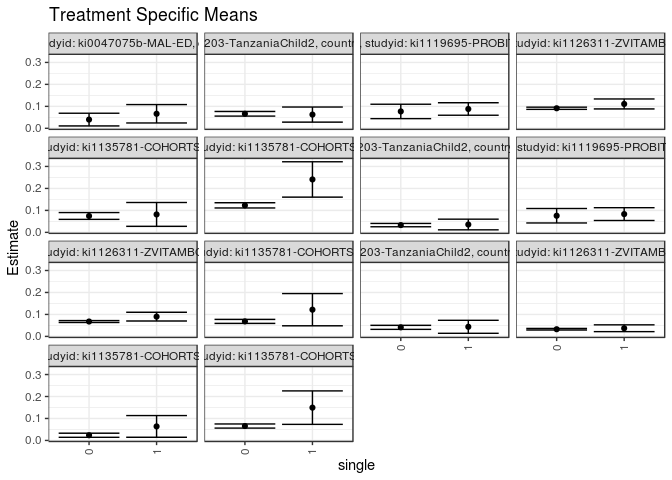

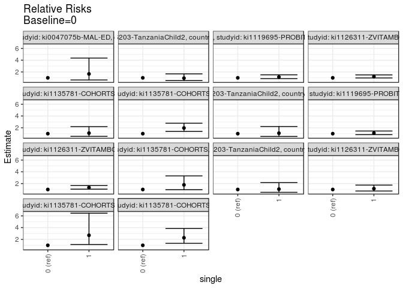

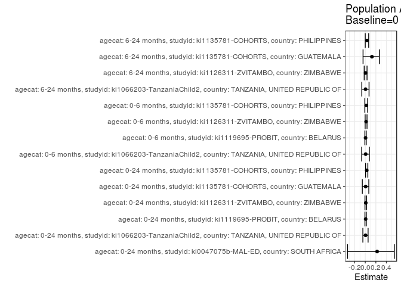

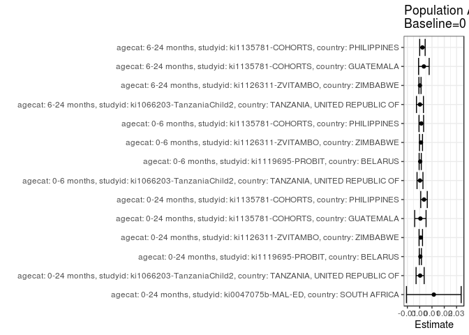

## Results Table

### Parameter: TSM

| agecat | studyid | country | intervention_level | baseline_level | estimate | ci_lower | ci_upper |
| --- | --- | --- | --- | --- | --- | --- | --- |
| 0-24 months | ki0047075b-MAL-ED | SOUTH AFRICA | 0 | NA | 0.0397727 | 0.0108547 | 0.0686907 |
| 0-24 months | ki0047075b-MAL-ED | SOUTH AFRICA | 1 | NA | 0.0661765 | 0.0243299 | 0.1080230 |
| 0-24 months | ki1066203-TanzaniaChild2 | TANZANIA, UNITED REPUBLIC OF | 0 | NA | 0.0661699 | 0.0556488 | 0.0766910 |
| 0-24 months | ki1066203-TanzaniaChild2 | TANZANIA, UNITED REPUBLIC OF | 1 | NA | 0.0625083 | 0.0281846 | 0.0968320 |
| 0-24 months | ki1119695-PROBIT | BELARUS | 0 | NA | 0.0769154 | 0.0441057 | 0.1097250 |
| 0-24 months | ki1119695-PROBIT | BELARUS | 1 | NA | 0.0880378 | 0.0595797 | 0.1164960 |
| 0-24 months | ki1126311-ZVITAMBO | ZIMBABWE | 0 | NA | 0.0912531 | 0.0862832 | 0.0962231 |
| 0-24 months | ki1126311-ZVITAMBO | ZIMBABWE | 1 | NA | 0.1108812 | 0.0882184 | 0.1335441 |
| 0-24 months | ki1135781-COHORTS | GUATEMALA | 0 | NA | 0.0746133 | 0.0590715 | 0.0901551 |
| 0-24 months | ki1135781-COHORTS | GUATEMALA | 1 | NA | 0.0816327 | 0.0274005 | 0.1358648 |
| 0-24 months | ki1135781-COHORTS | PHILIPPINES | 0 | NA | 0.1229353 | 0.1109597 | 0.1349108 |
| 0-24 months | ki1135781-COHORTS | PHILIPPINES | 1 | NA | 0.2408842 | 0.1603755 | 0.3213929 |
| 0-6 months | ki1066203-TanzaniaChild2 | TANZANIA, UNITED REPUBLIC OF | 0 | NA | 0.0330079 | 0.0254563 | 0.0405595 |
| 0-6 months | ki1066203-TanzaniaChild2 | TANZANIA, UNITED REPUBLIC OF | 1 | NA | 0.0357143 | 0.0114068 | 0.0600217 |
| 0-6 months | ki1119695-PROBIT | BELARUS | 0 | NA | 0.0756251 | 0.0427017 | 0.1085484 |
| 0-6 months | ki1119695-PROBIT | BELARUS | 1 | NA | 0.0831157 | 0.0539093 | 0.1123221 |
| 0-6 months | ki1126311-ZVITAMBO | ZIMBABWE | 0 | NA | 0.0677056 | 0.0633690 | 0.0720423 |
| 0-6 months | ki1126311-ZVITAMBO | ZIMBABWE | 1 | NA | 0.0899490 | 0.0700781 | 0.1098200 |
| 0-6 months | ki1135781-COHORTS | PHILIPPINES | 0 | NA | 0.0682594 | 0.0591229 | 0.0773959 |
| 0-6 months | ki1135781-COHORTS | PHILIPPINES | 1 | NA | 0.1216216 | 0.0482307 | 0.1950126 |
| 6-24 months | ki1066203-TanzaniaChild2 | TANZANIA, UNITED REPUBLIC OF | 0 | NA | 0.0412088 | 0.0320744 | 0.0503431 |
| 6-24 months | ki1066203-TanzaniaChild2 | TANZANIA, UNITED REPUBLIC OF | 1 | NA | 0.0437158 | 0.0140850 | 0.0733467 |
| 6-24 months | ki1126311-ZVITAMBO | ZIMBABWE | 0 | NA | 0.0326359 | 0.0291712 | 0.0361005 |
| 6-24 months | ki1126311-ZVITAMBO | ZIMBABWE | 1 | NA | 0.0371277 | 0.0216633 | 0.0525922 |
| 6-24 months | ki1135781-COHORTS | GUATEMALA | 0 | NA | 0.0235988 | 0.0142654 | 0.0329323 |
| 6-24 months | ki1135781-COHORTS | GUATEMALA | 1 | NA | 0.0638298 | 0.0143909 | 0.1132687 |
| 6-24 months | ki1135781-COHORTS | PHILIPPINES | 0 | NA | 0.0655156 | 0.0561568 | 0.0748744 |
| 6-24 months | ki1135781-COHORTS | PHILIPPINES | 1 | NA | 0.1492952 | 0.0731339 | 0.2254566 |

### Parameter: E(Y)

| agecat | studyid | country | intervention_level | baseline_level | estimate | ci_lower | ci_upper |
| --- | --- | --- | --- | --- | --- | --- | --- |
| 0-24 months | ki0047075b-MAL-ED | SOUTH AFRICA | NA | NA | 0.0512821 | 0.0267678 | 0.0757963 |
| 0-24 months | ki1066203-TanzaniaChild2 | TANZANIA, UNITED REPUBLIC OF | NA | NA | 0.0665263 | 0.0565020 | 0.0765506 |
| 0-24 months | ki1119695-PROBIT | BELARUS | NA | NA | 0.0774648 | 0.0450418 | 0.1098878 |
| 0-24 months | ki1126311-ZVITAMBO | ZIMBABWE | NA | NA | 0.0921526 | 0.0873423 | 0.0969629 |
| 0-24 months | ki1135781-COHORTS | GUATEMALA | NA | NA | 0.0751880 | 0.0602434 | 0.0901325 |
| 0-24 months | ki1135781-COHORTS | PHILIPPINES | NA | NA | 0.1264559 | 0.1145706 | 0.1383412 |
| 0-6 months | ki1066203-TanzaniaChild2 | TANZANIA, UNITED REPUBLIC OF | NA | NA | 0.0332632 | 0.0260497 | 0.0404766 |
| 0-6 months | ki1119695-PROBIT | BELARUS | NA | NA | 0.0760580 | 0.0435003 | 0.1086157 |
| 0-6 months | ki1126311-ZVITAMBO | ZIMBABWE | NA | NA | 0.0687831 | 0.0645599 | 0.0730062 |
| 0-6 months | ki1135781-COHORTS | PHILIPPINES | NA | NA | 0.0695739 | 0.0604740 | 0.0786738 |
| 6-24 months | ki1066203-TanzaniaChild2 | TANZANIA, UNITED REPUBLIC OF | NA | NA | 0.0414378 | 0.0327076 | 0.0501681 |
| 6-24 months | ki1126311-ZVITAMBO | ZIMBABWE | NA | NA | 0.0328660 | 0.0294989 | 0.0362331 |
| 6-24 months | ki1135781-COHORTS | GUATEMALA | NA | NA | 0.0270027 | 0.0174671 | 0.0365383 |
| 6-24 months | ki1135781-COHORTS | PHILIPPINES | NA | NA | 0.0677477 | 0.0583957 | 0.0770998 |

### Parameter: RR

| agecat | studyid | country | intervention_level | baseline_level | estimate | ci_lower | ci_upper |
| --- | --- | --- | --- | --- | --- | --- | --- |
| 0-24 months | ki0047075b-MAL-ED | SOUTH AFRICA | 0 | 0 | 1.0000000 | 1.0000000 | 1.000000 |
| 0-24 months | ki0047075b-MAL-ED | SOUTH AFRICA | 1 | 0 | 1.6638655 | 0.6347971 | 4.361155 |
| 0-24 months | ki1066203-TanzaniaChild2 | TANZANIA, UNITED REPUBLIC OF | 0 | 0 | 1.0000000 | 1.0000000 | 1.000000 |
| 0-24 months | ki1066203-TanzaniaChild2 | TANZANIA, UNITED REPUBLIC OF | 1 | 0 | 0.9446638 | 0.5333043 | 1.673322 |
| 0-24 months | ki1119695-PROBIT | BELARUS | 0 | 0 | 1.0000000 | 1.0000000 | 1.000000 |
| 0-24 months | ki1119695-PROBIT | BELARUS | 1 | 0 | 1.1446063 | 0.8660463 | 1.512764 |
| 0-24 months | ki1126311-ZVITAMBO | ZIMBABWE | 0 | 0 | 1.0000000 | 1.0000000 | 1.000000 |
| 0-24 months | ki1126311-ZVITAMBO | ZIMBABWE | 1 | 0 | 1.2150950 | 0.9835088 | 1.501213 |
| 0-24 months | ki1135781-COHORTS | GUATEMALA | 0 | 0 | 1.0000000 | 1.0000000 | 1.000000 |
| 0-24 months | ki1135781-COHORTS | GUATEMALA | 1 | 0 | 1.0940767 | 0.5453529 | 2.194916 |
| 0-24 months | ki1135781-COHORTS | PHILIPPINES | 0 | 0 | 1.0000000 | 1.0000000 | 1.000000 |
| 0-24 months | ki1135781-COHORTS | PHILIPPINES | 1 | 0 | 1.9594394 | 1.3833959 | 2.775346 |
| 0-6 months | ki1066203-TanzaniaChild2 | TANZANIA, UNITED REPUBLIC OF | 0 | 0 | 1.0000000 | 1.0000000 | 1.000000 |
| 0-6 months | ki1066203-TanzaniaChild2 | TANZANIA, UNITED REPUBLIC OF | 1 | 0 | 1.0819920 | 0.5276998 | 2.218509 |
| 0-6 months | ki1119695-PROBIT | BELARUS | 0 | 0 | 1.0000000 | 1.0000000 | 1.000000 |
| 0-6 months | ki1119695-PROBIT | BELARUS | 1 | 0 | 1.0990492 | 0.8347936 | 1.446956 |
| 0-6 months | ki1126311-ZVITAMBO | ZIMBABWE | 0 | 0 | 1.0000000 | 1.0000000 | 1.000000 |
| 0-6 months | ki1126311-ZVITAMBO | ZIMBABWE | 1 | 0 | 1.3285308 | 1.0555525 | 1.672105 |
| 0-6 months | ki1135781-COHORTS | PHILIPPINES | 0 | 0 | 1.0000000 | 1.0000000 | 1.000000 |
| 0-6 months | ki1135781-COHORTS | PHILIPPINES | 1 | 0 | 1.7817568 | 0.9603060 | 3.305881 |
| 6-24 months | ki1066203-TanzaniaChild2 | TANZANIA, UNITED REPUBLIC OF | 0 | 0 | 1.0000000 | 1.0000000 | 1.000000 |
| 6-24 months | ki1066203-TanzaniaChild2 | TANZANIA, UNITED REPUBLIC OF | 1 | 0 | 1.0608379 | 0.5199252 | 2.164498 |
| 6-24 months | ki1126311-ZVITAMBO | ZIMBABWE | 0 | 0 | 1.0000000 | 1.0000000 | 1.000000 |
| 6-24 months | ki1126311-ZVITAMBO | ZIMBABWE | 1 | 0 | 1.1376363 | 0.7401649 | 1.748552 |
| 6-24 months | ki1135781-COHORTS | GUATEMALA | 0 | 0 | 1.0000000 | 1.0000000 | 1.000000 |
| 6-24 months | ki1135781-COHORTS | GUATEMALA | 1 | 0 | 2.7047872 | 1.1335391 | 6.454011 |
| 6-24 months | ki1135781-COHORTS | PHILIPPINES | 0 | 0 | 1.0000000 | 1.0000000 | 1.000000 |
| 6-24 months | ki1135781-COHORTS | PHILIPPINES | 1 | 0 | 2.2787733 | 1.3420901 | 3.869194 |

### Parameter: PAR

| agecat | studyid | country | intervention_level | baseline_level | estimate | ci_lower | ci_upper |
| --- | --- | --- | --- | --- | --- | --- | --- |
| 0-24 months | ki0047075b-MAL-ED | SOUTH AFRICA | 0 | NA | 0.0115093 | -0.0107109 | 0.0337295 |
| 0-24 months | ki1066203-TanzaniaChild2 | TANZANIA, UNITED REPUBLIC OF | 0 | NA | 0.0003564 | -0.0029313 | 0.0036442 |
| 0-24 months | ki1119695-PROBIT | BELARUS | 0 | NA | 0.0005494 | -0.0003411 | 0.0014399 |
| 0-24 months | ki1126311-ZVITAMBO | ZIMBABWE | 0 | NA | 0.0008995 | -0.0005011 | 0.0023001 |
| 0-24 months | ki1135781-COHORTS | GUATEMALA | 0 | NA | 0.0005747 | -0.0040454 | 0.0051948 |
| 0-24 months | ki1135781-COHORTS | PHILIPPINES | 0 | NA | 0.0035206 | 0.0008614 | 0.0061799 |
| 0-6 months | ki1066203-TanzaniaChild2 | TANZANIA, UNITED REPUBLIC OF | 0 | NA | 0.0002553 | -0.0021456 | 0.0026561 |
| 0-6 months | ki1119695-PROBIT | BELARUS | 0 | NA | 0.0004329 | -0.0004536 | 0.0013194 |
| 0-6 months | ki1126311-ZVITAMBO | ZIMBABWE | 0 | NA | 0.0010774 | -0.0001414 | 0.0022963 |
| 0-6 months | ki1135781-COHORTS | PHILIPPINES | 0 | NA | 0.0013145 | -0.0005579 | 0.0031870 |
| 6-24 months | ki1066203-TanzaniaChild2 | TANZANIA, UNITED REPUBLIC OF | 0 | NA | 0.0002291 | -0.0026040 | 0.0030621 |
| 6-24 months | ki1126311-ZVITAMBO | ZIMBABWE | 0 | NA | 0.0002302 | -0.0006539 | 0.0011143 |
| 6-24 months | ki1135781-COHORTS | GUATEMALA | 0 | NA | 0.0034039 | -0.0009036 | 0.0077114 |
| 6-24 months | ki1135781-COHORTS | PHILIPPINES | 0 | NA | 0.0022321 | 0.0000179 | 0.0044463 |

### Parameter: PAF

| agecat | studyid | country | intervention_level | baseline_level | estimate | ci_lower | ci_upper |
| --- | --- | --- | --- | --- | --- | --- | --- |
| 0-24 months | ki0047075b-MAL-ED | SOUTH AFRICA | 0 | NA | 0.2244318 | -0.3345633 | 0.5492863 |
| 0-24 months | ki1066203-TanzaniaChild2 | TANZANIA, UNITED REPUBLIC OF | 0 | NA | 0.0053579 | -0.0453095 | 0.0535694 |
| 0-24 months | ki1119695-PROBIT | BELARUS | 0 | NA | 0.0070924 | -0.0060260 | 0.0200397 |
| 0-24 months | ki1126311-ZVITAMBO | ZIMBABWE | 0 | NA | 0.0097608 | -0.0055483 | 0.0248368 |
| 0-24 months | ki1135781-COHORTS | GUATEMALA | 0 | NA | 0.0076433 | -0.0557292 | 0.0672117 |
| 0-24 months | ki1135781-COHORTS | PHILIPPINES | 0 | NA | 0.0278408 | 0.0066246 | 0.0486040 |
| 0-6 months | ki1066203-TanzaniaChild2 | TANZANIA, UNITED REPUBLIC OF | 0 | NA | 0.0076738 | -0.0671750 | 0.0772729 |
| 0-6 months | ki1119695-PROBIT | BELARUS | 0 | NA | 0.0056920 | -0.0072196 | 0.0184380 |
| 0-6 months | ki1126311-ZVITAMBO | ZIMBABWE | 0 | NA | 0.0156641 | -0.0021944 | 0.0332045 |
| 0-6 months | ki1135781-COHORTS | PHILIPPINES | 0 | NA | 0.0188938 | -0.0082968 | 0.0453512 |
| 6-24 months | ki1066203-TanzaniaChild2 | TANZANIA, UNITED REPUBLIC OF | 0 | NA | 0.0055276 | -0.0652363 | 0.0715907 |
| 6-24 months | ki1126311-ZVITAMBO | ZIMBABWE | 0 | NA | 0.0070034 | -0.0202605 | 0.0335388 |
| 6-24 months | ki1135781-COHORTS | GUATEMALA | 0 | NA | 0.1260570 | -0.0417454 | 0.2668302 |
| 6-24 months | ki1135781-COHORTS | PHILIPPINES | 0 | NA | 0.0329477 | -0.0000778 | 0.0648826 |